# Surname-Based Race Inference

A federal table of names, a county, and one line of arithmetic that decides who counts as a Black voter

Democracy’s Data

Last updated September 13, 2026 at 10:53a EDT

The United States Census Bureau publishes a table about surnames. For any surname held by at least a hundred Americans, it gives the share of the people carrying it who are white, Black, Asian, American Indian, Hispanic, or of two or more races. It is free, it requires no login, and between them its rows account for 298,898,231 people.

Multiply that table by a second public table, the racial make-up of the county somebody lives in, and out comes a probability that a named person belongs to a racial category. The procedure is called **Bayesian Improved Surname Geocoding**, BISG for short: *surname* because it starts from the name table, *geocoding* because the address is turned into a place on the census map, and *Bayesian* because the two are combined by Bayes’ rule, the arithmetic for revising a probability when new evidence arrives. Elliott and colleagues (2009) developed it for health research,[^1] Imai and Khanna (2016) brought it into political science,[^2] and it is now routine evidence in federal voting-rights and lending-discrimination cases.[^3] Courts use it to decide how many Black voters a district contains.

Nothing in that description is a euphemism. Somebody’s race is being inferred, without their knowledge, from their name and their address, by multiplying two spreadsheets published by their own government. So ask the plain question underneath. **Can a name tell you someone’s race?**

## The test

Two federal tables answer it, because the method has exactly two ingredients and these are the published versions of both. The first is the Census Bureau’s *Frequently Occurring Surnames* tabulation: the 2020 edition, which everything below runs on, downloadable as a spreadsheet at https://www2.census.gov/topics/genealogy/2020surnames/, and the 2010 edition it replaced (https://www2.census.gov/topics/genealogy/2010surnames/names.zip), kept beside it because the two handle small numbers differently. The second is the Bureau’s population estimate for every county as of July 2024 — the 2020 count carried forward by births, deaths and moves — downloadable at https://www2.census.gov/programs-surveys/popest/datasets/2020-2024/counties/asrh/: 3,144 counties in the same six categories.

There is no third public table that would do better, and what would genuinely be better is not a table at all. The honest input is a record of what people say about themselves. No such record exists in a voter file, and the reason is not cost: American states decided not to ask. The BISG check brief works in one of the few counties where a state did.

The two tables are joined through a person, which is where the assumptions stack up. Join Keys and Crosswalks is the reading on what a join key is and how one fails. It also covers the repair when two files carry different keys: a crosswalk, a table that translates one set of identifiers into another.

## The data

**Neither table was made for this.** The surname file sits under genealogy on the Bureau’s servers, and its intended reader is somebody tracing a family. The county file is a different kind of number altogether: one is a count taken on a single day, the other a model carried forward a year at a time. The method multiplies them as though they were the same sort of object.

One row of the surname file looks like this.

| Surname | Rank | People holding it | White | Black | Asian/PI | Am. Indian | Two or more | Hispanic |
| --- | --- | --- | --- | --- | --- | --- | --- | --- |
| SMITH | 1 | 2,369,644 | 67.9949 | 22.618 | 0.681073 | 0.833205 | 4.37243 | 3.5004 |

The columns are `name`, `rank`, `count`, and the six shares `pctwhite`, `pctblack`, `pctapi`, `pctaian`, `pct2prace` and `pcthispanic`, which are mutually exclusive and sum to 100. The county file carries `fips`, `county`, `state`, `pop` and the same six groups.

The join runs on two keys and neither is a person. The **surname**, upper-cased, matches somebody to a row of the name table; the **five-digit county code** matches them to a row of the county table. Nothing joins the two tables to each other. A person is what makes them meet, and the assumption that both lists describe the same population at the same moment is a third assumption on top of each file’s own.

Both tables needed cleaning, and one decision is the whole brief. In the 2010 file a cell too small to publish safely is written `(S)`. Read carelessly that is a zero; the table used here keeps it as a missing value instead, preserving the difference between *nobody* and *too few to say*. 315,341 of the 973,524 cells in the six percentage columns are withheld, 32.4% of them, and dropping incomplete rows would throw away most American surnames.

The 2020 edition answers the same problem in the opposite way. It suppresses nothing, and instead publishes every count with noise added to protect the people in it. Noise added to a small count can push it below zero, so the Bureau ships the trimmed table and, beside it, the same table with the negatives left in. 54,147 of the 156,621 surnames carry at least one:

| Last name | Category | Published | With negatives | People with that name |
| --- | --- | --- | --- | --- |
| CHEUNG | aian | 0 | -2 | 19,577 |
| FENG | aian | 0 | -3 | 16,357 |
| FU | aian | 0 | -1 | 12,092 |
| XIAO | aian | 0 | -1 | 10,322 |
| GUAN | aian | 0 | -2 | 10,141 |
| TA | aian | 0 | -2 | 9,217 |

Read the third and fourth columns together. The published file says no American Indian or Alaska Native person is named CHEUNG; the other, same office and same release, says minus two. **Minus two people is not a mistake. It is what the protection costs, made visible.** The method is most confident about a name in proportion to how lopsided that name is, so it is most sure of itself exactly where the file is least able to support it.

The county figures are the Bureau’s estimate for 1 July 2024, all ages and both sexes together, with the Bureau’s categories collapsed to the surname file’s six.

> **Before you read on, write a ratio down.**

> Of the 25,800 surnames held by more than a thousand people, some number are more than 90% white and some number are more than 90% Black. **For every surname that is more than 90% Black, how many do you think are more than 90% white?** Four to one? Ten to one? Fifty to one?

> One ratio, on paper, before your eye reaches the figures below.

## What it says about democracy

Start with the thousand most common surnames, on the two shares that between them account for nearly all of their bearers.

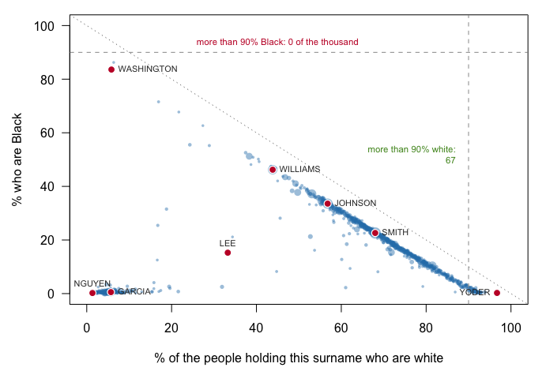

*Hover a circle for the name and the counts behind it.*

**Figure 1. The thousand most common surnames in America, by the share of their bearers who are white and the share who are Black.** A scatter fits this question, because the question is whether the two shares trade off against each other. Each circle is one surname, sized by how many people hold it, and the diagonal is where a name with only white and Black bearers would have to sit. Together these names cover 39.7% of everyone in the file. The right-hand wall is crowded and the top is empty: 67 of the thousand are more than 90% white and 0 are more than 90% Black, the highest point being PIERRE at 86.2%.

Three of those crowded middle points are the commonest names in America:

| Surname | Rank | People | White | Black | Asian/PI | Am. Indian | Two or more | Hispanic |
| --- | --- | --- | --- | --- | --- | --- | --- | --- |
| SMITH | 1 | 2,369,644 | 67.9949 | 22.6180 | 0.681073 | 0.833205 | 4.37243 | 3.50040 |
| JOHNSON | 2 | 1,858,234 | 56.7854 | 33.5641 | 0.707984 | 0.880675 | 4.72432 | 3.33752 |
| WILLIAMS | 3 | 1,561,395 | 43.8243 | 46.2204 | 0.589793 | 0.781673 | 5.08475 | 3.49905 |

**Williams is 43.8% white and 46.2% Black**, and it is the 3rd most common surname in America, held by 1,561,395 people. Smith and Johnson are ranks 1 and 2. For names like these the surname settles nothing, and that is not rare: for 23.6% of the people this file covers, no group reaches 60%.

Now count past the 90% line, on every surname held by more than a thousand people.

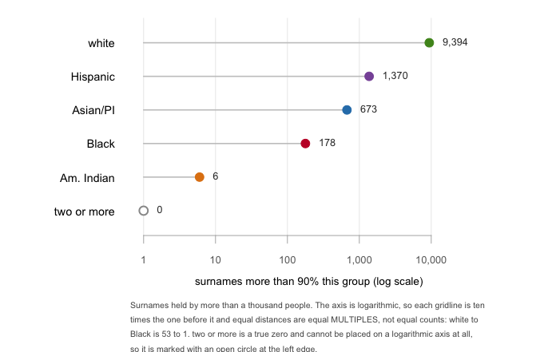

Surnames held by more than a thousand people. The axis is logarithmic, so each gridline is ten times the one before it and equal distances are equal MULTIPLES, not equal counts: white to Black is 53 to 1. two or more is a true zero and cannot be placed on a logarithmic axis at all, so it is marked with an open circle at the left edge.

**Figure 2. How many surnames are more than 90% one group.** The axis is logarithmic, so equal distances are equal *multiples* rather than equal counts, which is why these are dots to be read by position and not bars to be read by length.

9,394 surnames are more than 90% white. 178 are more than 90% Black. That is a ratio of about 53 to 1, for a group that is roughly 13% of the country rather than one-hundredth of it. Compare it with the ratio you wrote down. Four or five to one is the reasonable expectation, and it is wrong by more than an order of magnitude. **The group the Voting Rights Act was written to protect is the group whose surnames carry the least information.**

That is not a quirk of the data and not a flaw in the Bureau’s processing. It is history sitting in a spreadsheet. Enslaved people were given, or took, the surnames of enslavers, and after emancipation those names stayed. Black and white Americans have shared a common stock of surnames for a hundred and sixty years. The exceptions show the mechanism from the other side. Washington is the most identifiably Black common surname in America, 83.6% of the 172,075 people who carry it, and historians’ best explanation is that freed people chose the names of presidents associated with liberty.[^4]

So what carries the inference for everybody else? The address. Bayes’ rule combines the two tables in one line. Start from what the name alone says, the **prior**: the probability before the address is considered. Multiply it by how much more, or less, common each group is in the person’s county than in the country. Rescale the six results so they add to 100 and you have the **posterior**: the probability after the evidence is in. In symbols, the probability that a person of surname $s$ in county $g$ belongs to group $r$ is

$$P(r \mid s, g) \;\propto\; \frac{P(r \mid s)\,P(r \mid g)}{P(r)}$$

| Group | SMITH, by name (%) | The Bronx (%) | The country (%) | Bronx ÷ country | Name × ratio | Posterior (%) |
| --- | --- | --- | --- | --- | --- | --- |
| white | 68.0 | 8.9 | 57.5 | 0.15 | 10.5 | 13.8 |
| Black | 22.6 | 29.6 | 12.6 | 2.35 | 53.1 | 69.8 |
| Asian/PI | 0.7 | 4.7 | 6.7 | 0.70 | 0.5 | 0.6 |
| Am. Indian | 0.8 | 0.3 | 0.7 | 0.42 | 0.4 | 0.5 |
| two or more | 4.4 | 1.1 | 2.5 | 0.45 | 1.9 | 2.6 |
| Hispanic | 3.5 | 55.4 | 20.0 | 2.77 | 9.7 | 12.7 |

Read the Black row. Smith is 22.6% Black by name. The Bronx is 29.6% Black against 12.6% for the country, 2.35 times the national share, so the name’s 22.6 becomes 53.1. Do the same in the other five rows, add the six products, and Black’s share of the total is 69.8%. White runs the other way: 68.0% by name, times 0.15, comes out at 13.8%. Nothing about the name changed. The same arithmetic, for two names in three counties:

| Surname and place | White | Black | Asian/PI | Am. Indian | Two or more | Hispanic |
| --- | --- | --- | --- | --- | --- | --- |
| SMITH in Allegheny County, PA | 75.5 | 19.7 | 0.4 | 0.1 | 3.8 | 0.5 |
| SMITH in the Bronx, NY | 13.8 | 69.8 | 0.6 | 0.5 | 2.6 | 12.7 |
| LEE in Allegheny County, PA | 45.2 | 16.3 | 33.5 | 0.2 | 4.4 | 0.4 |
| LEE in Honolulu County, HI | 2.6 | 0.8 | 87.8 | 0.1 | 8.4 | 0.3 |

**Smith is 68.0% white nationally. A Smith in the Bronx is 69.8% Black.** The name did not change; the arithmetic stopped ignoring where the person lives. Lee runs the other way, resolving to 45.2% white in Allegheny County and 87.8% Asian in Honolulu. Three letters, opposite conclusions.

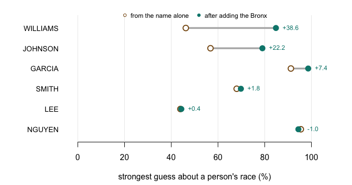

*The tan end is the name alone; the teal end is the name plus one county. Hover a rod for both figures and the change between them.*

**Figure 3. How much six surnames move when one county is added.** Each rod is one surname: the hollow end is the strongest claim the name alone will support, the solid end is the strongest claim it supports once the person is placed in the Bronx.

NGUYEN barely moves. WILLIAMS moves +38.6 points. That is Bayes’ rule behaving correctly, because a sharp starting guess is hard to move and a flat one is easy. But follow the consequence. The names that need help are the *common* ones: Smith, Johnson and Williams are three of the five most frequent surnames in America. Nguyen and Garcia are precise, and describe a much smaller share of it.

**So for most Americans this is substantially a method for inferring race from an address.** Told only the name, you would learn almost nothing; told only the county, you would learn most of what the model produces. The consequence is worth saying rather than implying. **The method is accurate because American neighbourhoods are segregated.** It works well in the Bronx precisely to the extent that the Bronx is not integrated, so the estimate borrows its precision from the condition the Voting Rights Act exists to address.

## What this brief cannot tell you

**Nothing here has been checked against a known answer.** Every number above describes what the method *does*, not how often it is right, and those are different questions. The BISG check brief is the test; this one is the anatomy.

**Nor can any of it be said about an individual.** The output is a statement about a population: of all the Smiths in the Bronx, roughly 69.8% are Black. Every use of the method takes a number true on average and attaches it to somebody in particular.

**The two tables describe different years.** The surname list is a count from a census; the county file is a model carried forward to 2024. Anyone born or arrived in between sits in one file and not the other, and no column in either says how much that costs.

## What you should have learned

- The whole method is one line of arithmetic: what a name implies, times what a county implies, divided by the national share of each group.
- The name carries almost nothing for most Americans. 0 of the thousand commonest surnames are more than 90% Black, and for 23.6% of the people this file covers no group reaches 60%.
- Of the 25,800 surnames held by more than a thousand people, 9,394 are more than 90% white and 178 more than 90% Black, a ratio of about 53 to 1 for a group that is 13% of the country.
- Geography supplies what the name cannot. Smith is 68.0% white nationally and 69.8% Black in the Bronx, and the name that gains most from one county gains +38.6 points.
- Neither edition of the file can give you a small cell you can trust: 2010 withholds 315,341 cells outright, and 2020 publishes noised counts that go negative in 54,147 of 156,621 surnames.

## Extensions

None of these is answered above, and every one can be answered by sorting or grouping the tables the Sources section hands over.

Two stretch ideas point past the spreadsheet. The `wru` package, a free add-on for the R statistical language written by Imai’s group (https://github.com/kosukeimai/wru), implements the full version, with first names, age, sex and geography down to the census block. Run it on one name, and see how much of the extra sharpness comes from the finer geography. And the Consumer Financial Protection Bureau published its own version of this method in 2014 for lending cases; read what it says about error rates against what the tables above imply.

## Sources

**Data**

- U.S. Census Bureau, *Frequently Occurring Surnames from the 2010 Census* — every surname held by 100 or more people, with the racial composition of its bearers, and cells too small to publish safely suppressed. https://www2.census.gov/topics/genealogy/2010surnames/names.zip
- U.S. Census Bureau, *Frequently Occurring Surnames from the 2020 Census*, published twice: once trimmed, once with the negatives left in. https://www.census.gov/topics/population/genealogy/data/2020_surnames.html (that page no longer answers; the two spreadsheets are at https://www2.census.gov/topics/genealogy/2020surnames/ and the release is described at https://www.census.gov/topics/population/genealogy/data/2020_names.html).
- Joshua Comenetz, *Frequently Occurring Surnames in the 2010 Census* (U.S. Census Bureau, 2016) — how the table was made. https://www2.census.gov/topics/genealogy/2010surnames/surnames.pdf
- U.S. Census Bureau, Population Estimates Program, county characteristics file for 2024, collapsed to the same six categories. https://www2.census.gov/programs-surveys/popest/datasets/2020-2024/counties/asrh/

**Literature**

- Elliott, M. N., Morrison, P. A., Fremont, A., McCaffrey, D. F., Pantoja, P. and Lurie, N. (2009). “Using the Census Bureau’s Surname List to Improve Estimates of Race/Ethnicity and Associated Disparities.” *Health Services and Outcomes Research Methodology* 9(2): 69–83. https://doi.org/10.1007/s10742-009-0047-1
- Imai, K. and Khanna, K. (2016). “Improving Ecological Inference by Predicting Individual Ethnicity from Voter Registration Records.” *Political Analysis* 24(2): 263–272. https://doi.org/10.1093/pan/mpw001
- Consumer Financial Protection Bureau (2014). *Using Publicly Available Information to Proxy for Unidentified Race and Ethnicity.* https://files.consumerfinance.gov/f/201409_cfpb_report_proxy-methodology.pdf
- *Thornburg v. Gingles*, 478 U.S. 30 (1986). https://www.law.cornell.edu/supremecourt/text/478/30
- *NAACP, Spring Valley Branch v. East Ramapo Central School District* (S.D.N.Y. 2020; affirmed, 2d Cir. 2020) — BISG estimates accepted as evidence of voters’ race. https://clearinghouse.net/case/43350/

**The data itself**

Every figure above is drawn from these tables. They are plain CSV, they open in a spreadsheet, and they are yours to take further.

`census_surnames.csv`, `census_surnames_2010.csv`, `county_race.csv`, `surnames_2010_vs_2020.csv`, `surnames_2020_facts.csv`, `surnames_2020_negatives.csv`, `surnames_2020_top100.csv`, `surnames_vintage_facts.csv`

Why this data cannot be fetched again

```
The core file behind this chapter could not be downloaded when this book's
copy was built, and the story of that failure is worth having before
you try.

WHY NOT. The chapter is built on U.S. Census Bureau, "Frequently
Occurring Surnames from the 2010 Census" — every surname held by 100 or
more people, with the share of its bearers in each of six race and
ethnicity categories. In August 2026 its address,
https://www2.census.gov/topics/genealogy/2010surnames/names.zip
answered as if everything were fine, but what came back was a 247-byte
page reading "Request Rejected" instead of the zip — while everything
else in the same directory, and the whole 2020 release, arrived
normally. A server that refuses one file and serves its neighbors may
change its mind without notice, in either direction. So try the address
first: if a real zip arrives (about 13 MB, holding the table as a CSV
and a spreadsheet), you hold the genuine article, and the numbers below
will tell you so. The mind-change has in fact happened once already: on
16 August 2026 the same address served the real zip, and that capture —
the Bureau's own artifact, not a local re-assembly — ships with this
chapter's data as names.zip, beside the CSV extracted from it. If the
address refuses you, nothing is lost.

WHAT EXISTS INSTEAD. The matching 2020 release downloads normally:
"Frequently Occurring Surnames in the 2020 Census", spreadsheets at
https://www2.census.gov/topics/genealogy/2020surnames/
(the last-name files are the ones named LastNames). Most of what this
chapter does can be repeated on it. The differences you would see are
real differences between the two censuses, plus a change in how much
the Bureau suppressed.

WHAT YOU CAN STILL CHECK. However you obtain the 2010 file — the
address relenting, the copy shipped with this chapter, an archive, a
colleague — these numbers say whether you are holding the same object:
- 162,254 data rows, of which the last is a residual called
  ALL OTHER NAMES rather than a name
- eleven columns: name, rank, count, two proportion columns, and six
  percentage columns for the race categories, with suppressed cells
  printed as (S)
- SMITH first, at 2,442,977 bearers
- the zip itself: 12,874,389 bytes, unpacking to that CSV and an .xlsx
  of the same table
```

[^1]: Marc N. Elliott et al., “Using the Census Bureau’s Surname List to Improve Estimates of Race/Ethnicity and Associated Disparities,” *Health Services and Outcomes Research Methodology* 9, no. 2 (2009): 69–83, https://doi.org/10.1007/s10742-009-0047-1.
[^2]: Kosuke Imai and Kabir Khanna, “Improving Ecological Inference by Predicting Individual Ethnicity from Voter Registration Records,” *Political Analysis* 24, no. 2 (2016): 263–272, https://doi.org/10.1093/pan/mpw001.
[^3]: The Consumer Financial Protection Bureau adopted it for fair-lending enforcement in 2014: *Using Publicly Available Information to Proxy for Unidentified Race and Ethnicity*, https://files.consumerfinance.gov/f/201409_cfpb_report_proxy-methodology.pdf. In *NAACP v. East Ramapo Central School District* (S.D.N.Y. 2020, affirmed by the Second Circuit that December), a school board’s at-large elections were struck down under the Voting Rights Act on BISG estimates of voters’ race; the case file is at https://clearinghouse.net/case/43350/.
[^4]: The Bureau’s own report on the 2010 table singles the name out: Joshua Comenetz, *Frequently Occurring Surnames in the 2010 Census* (U.S. Census Bureau, 2016), https://www2.census.gov/topics/genealogy/2010surnames/surnames.pdf. On the why, and on how uncertain historians are about it: Associated Press, “Washington: the ‘blackest name’ in America,” 2011, https://www.nbcnews.com/id/wbna41704238.